# Biostatistics - Nonparametric Survival

Rob Leonard (robleonard@tamu.edu)

# 1) Kaplan-Meier

**1a) Compute separate Kaplan-Meier survival curves for each of the two treatment groups. Make Plots.**

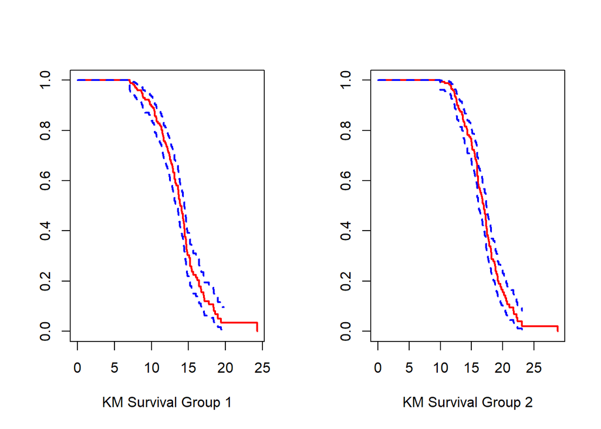

```r
data1 = read.csv("surv_times_data.csv", header=TRUE, sep = ",")   # read in original data
library(survival)
par(mfrow=c(1,2))  # set plots as side-by-side
data1$SurvObjGrp1 <- with(data1, Surv(Y1, event=Delta1))   # Delta1==1 means event occurred.  0 is right censored
kmGrp1 <- survfit(SurvObjGrp1 ~ 1, data = data1, conf.type = "log-log")  # create survival curves for group 1
plot(kmGrp1, col=c("red", "blue", "blue"), lwd=2, xlab = "KM Survival Group 1")  # change colors
data1$SurvObjGrp2 <- with(data1, Surv(Y2, event=Delta2))   # Delta1==1 means event occurred.  0 is right censored
kmGrp2 <- survfit(SurvObjGrp2 ~ 1, data = data1, conf.type = "log-log")  # create survival curves for group 1
plot(kmGrp2, col=c("red", "blue", "blue"), lwd=2, xlab = "KM Survival Group 2")  # change colors
```

**1b) Estimate mean survival time and a 95% CI using KM for each group.**

```r
print(kmGrp1, print.rmean=TRUE)
```

```
## Call: survfit(formula = SurvObjGrp1 ~ 1, data = data1, conf.type = "log-log")
##
##          n     events     *rmean *se(rmean)     median    0.95LCL    0.95UCL
##    183.000    110.000     13.985      0.306     13.873     13.331     14.455
##     * restricted mean with upper limit =  24.3
```

```r
print(kmGrp2, print.rmean=TRUE)
```

```
## Call: survfit(formula = SurvObjGrp2 ~ 1, data = data1, conf.type = "log-log")
##
##          n     events     *rmean *se(rmean)     median    0.95LCL    0.95UCL
##    183.000    119.000     17.053      0.295     16.950     16.080     17.441
##     * restricted mean with upper limit =  28.8
```

```r
(ciGrp1 = c(13.985-1.96*0.306,13.985+1.96*0.306) )
```

```
## [1] 13.38524 14.58476
```

```r
(ciGrp2 = c(17.053-1.96*0.295,17.053+1.96*0.295) )
```

```
## [1] 16.4748 17.6312
```

The estimated mean for group 1 is 13.985. The estimated 95% CI for the group 1 mean is (13.38524, 14.58476). The estimated mean for group 2 is 17.053. The estimated 95% CI for group 2 mean is (16.4748, 17.6312).

**1c) Obtain the estimate and 95% CI for the 1st, 2nd, and 3rd quartiles of the survival times for each group, based on the Kaplan-Meier survival curves.** For group 1:

```r
quantile(kmGrp1, prob=c(0.25, 0.5, 0.75), conf.int=TRUE)
```

```
## $quantile
##       25       50       75
## 11.98686 13.87340 15.38351
##
## $lower
##       25       50       75
## 11.25834 13.33085 14.73089
##
## $upper
##       25       50       75
## 12.63385 14.45479 16.66306
```

For group 2:

```r
quantile(kmGrp2, prob=c(0.25, 0.5, 0.75), conf.int=TRUE)
```

```
## $quantile
##       25       50       75
## 15.04833 16.95023 18.82140
##
## $lower
##       25       50       75
## 13.92103 16.07963 18.03539
##
## $upper
##       25       50       75
## 15.78946 17.44139 19.76284
```

|  | 1st Quartile | 2nd Quartile | 3rd Quartile |
| --- | --- | --- | --- |
| **Group1** |  |  |  |
| Estimate | 11.98686 | 13.87340 | 15.38351 |
| Confidence Interval | (11.25834,12.63385 ) | ( 13.33085 ,14.45479 ) | ( 14.73089 ,16.66306 ) |
| **Group2** |  |  |  |
| Estimate | 15.04833 | 16.95023 | 18.82140 |
| Confidence Interval | (13.92103 ,15.78946 ) | ( 16.07963 ,17.44139 ) | ( 18.03539 ,19.76284 ) |

**1d) Plot hazard functions. Apply log rank test to the 2 survival curves.**

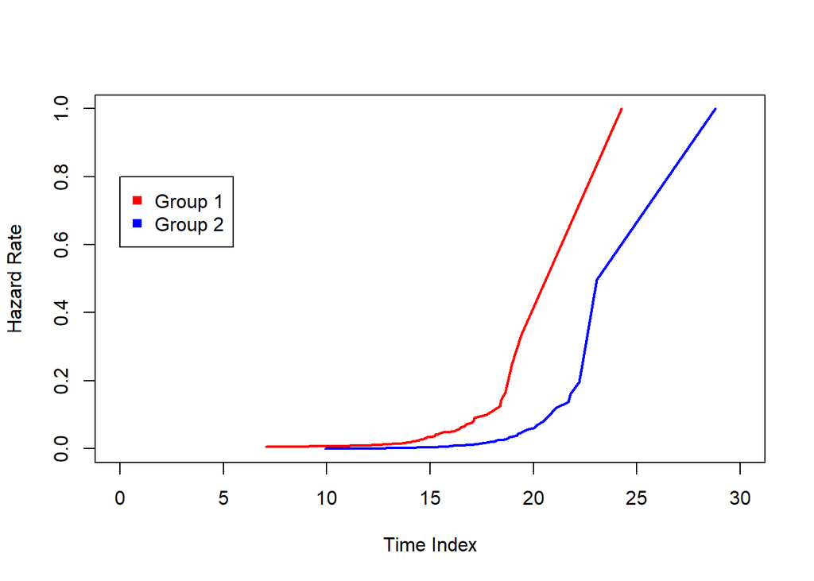

```r
data1dg1 <- data.frame(kmGrp1$n.censor, kmGrp1$n.event, kmGrp1$n.risk, kmGrp1$time)
hazGrp1 <- data1dg1$kmGrp1.n.event/data1dg1$kmGrp1.n.risk
hazard1 <- cbind(data1dg1$kmGrp1.time,hazGrp1)
hazard1 <- subset(hazard1, hazGrp1!=0)
plot(hazard1, col="red", lwd=2,  ylab = "Hazard Rate", xlab = "Time Index", type = "l", xlim=c(0,30), ylim=c(0,1))

data1dg2 <- data.frame(kmGrp2$n.censor, kmGrp2$n.event, kmGrp2$n.risk, kmGrp2$time)
hazGrp2 <- data1dg2$kmGrp2.n.event/data1dg2$kmGrp2.n.risk
hazard2 <- cbind(data1dg2$kmGrp2.time,hazGrp2)
hazard2 <- subset(hazard2, hazGrp2!=0)
par(new=T);
plot(hazard2, col="blue", lwd=2,  ylab = "", xlab = "", type = "l", xlim=c(0,30), axes=FALSE)
legend(x=0,y=0.8,c("Group 1","Group 2"),col=c("red","blue"),pch=c(15,15))
```

The plots of the hazard rates look fairly similar in shape but group 2 is shifted right in time.

```r
# combine data into a single dataset
dataA <- data.frame(data1[1],data1[2],data1[4])
dataA[4] <- 0
names(dataA)[1:4] = c("X","Y","Delta","Grp")
dataB <- data.frame(data1[1],data1[3],data1[5])
dataB[4] <- 1
names(dataB)[1:4] = c("X","Y","Delta","Grp")
data2 <- merge(dataA,dataB, all = TRUE)
# run log rank test
logrank1 <- survdiff(Surv(Y, event=Delta)~Grp, data = data2, rho = 0)
logrank1
```

```
## Call:
## survdiff(formula = Surv(Y, event = Delta) ~ Grp, data = data2,
##     rho = 0)
##
##         N Observed Expected (O-E)^2/E (O-E)^2/V
## Grp=0 183      110     62.8      35.5      51.9
## Grp=1 183      119    166.2      13.4      51.9
##
##  Chisq= 51.9  on 1 degrees of freedom, p= 6e-13
```

We are testing $H_0: \lambda_1(t)=\lambda_2(t)$ for all t, versus $H_a:\lambda_1(t) \neq \lambda_2(t)$ for at least one t. The Chi-Square test statistic is very high at 51.9 and the p-value is very low at 6*$10^{-13}$. Thus, we reject the null hypothesis that the hazard rates are equal.

# Problem 2

**2a) Obtain the analytical form of the survival function, and plot it over time between 0 and 5.**

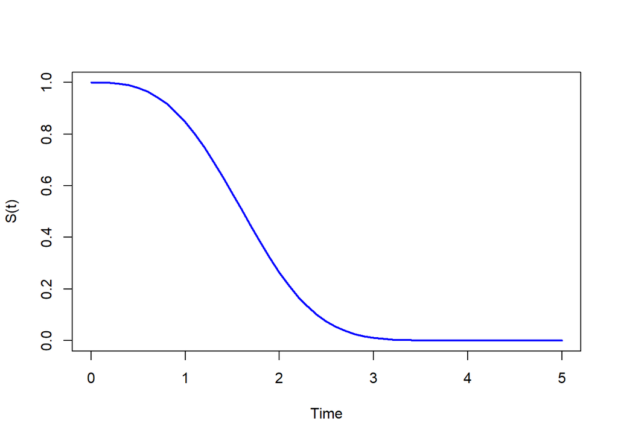

```r
time <- seq(0,5,0.1)
lambdaProb2 <- 0.5*(time^2)
fProb2 <- function(t) exp(-integrate( function(x) .5*(x^2), lower = 0, upper=t)$value)
survProb2 <- lapply(time, fProb2)
plot(time, survProb2, type = "l", lwd=2, col = "blue", xlim=c(0,5), ylab = "S(t)", xlab="Time")
```

**2b) Calculate the mean of T.**  
The mean of T is the area under the survival curve. We have the exact form of the survival curve so the mean is the integral from 0 to infinity which is **1.62**.

```r
meanProb2 <- integrate( function(x) exp(-(1/6)*x^3), lower = 0, upper=Inf)
meanProb2
```

```
## 1.622651 with absolute error < 1.6e-06
```

**2c) Obtain the pth percentile of T. Also calculate values of 1st, 2nd and 3rd quartiles.** The pth percentile is the smallest time at which the survival function is less than or equal to (1-p): $q_p = \inf[t: S(t) \leq (1-p)]$ => $inf[t: e^{-(1/6)t^3)} \leq (1-p)]$ => $inf[t: 1-e^{-(1/6)t^3)} \geq p]$

```r
(first <- (-6*log(.75))^(1/3))
```

```
## [1] 1.199558
```

```r
(second <- (-6*log(.5))^(1/3))
```

```
## [1] 1.608146
```

```r
(third <- (-6*log(.25))^(1/3))
```

```
## [1] 2.026137
```

The first, second and third quartiles are **1.199558, 1.608146 and 2.026137**, respectively.

# 3) Kidney Data

**3a) Obtain the estimate and the 95% CI’s for the Survival function for the Kidney data using KM and NA methods. Plot them in same graph.**

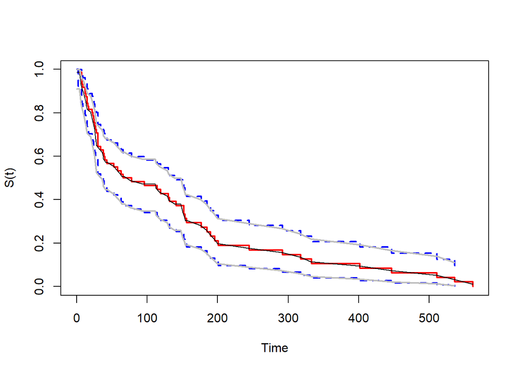

```r
data(kidney)
kidney$SurvObj <- with(kidney, Surv(time, status))
kidneykm <- survfit(SurvObj ~ 1, data = kidney, conf.type = "log-log")
plot(kidneykm, col=c("red","blue","blue"),lwd=2, xlab="Time", ylab="S(t)")
# now plot Nelson Aalen
hazardNA3 <- kidneykm$n.event/kidneykm$n.risk
cum.hazard3 <- cumsum(hazardNA3)
var3 <- cumsum( kidneykm$n.event*(kidneykm$n.risk-kidneykm$n.event)/(((kidneykm$n.risk)^2)*(kidneykm$n.risk-1)))
sd3 <- sqrt(var3)
par(new=T);
plot(kidneykm$time, exp(-cum.hazard3), ylim=c(0, 1), ylab="", type="l", col="black", xlab="", axes=FALSE)
par(new=T);
plot(kidneykm$time, exp(-exp(log(cum.hazard3)-1.96*sd3/cum.hazard3)), col="gray",
     lwd=2, ylim=c(0, 1), type="l", ylab="", xlab="", axes=FALSE)
par(new=T);
plot(kidneykm$time, exp(-exp(log(cum.hazard3)+1.96*sd3/cum.hazard3)),  col="gray",
     lwd=2, ylim=c(0, 1), type="l", ylab="", xlab="", axes=FALSE)
```

**3b) Obtain the estimate and 95% CI for the mean using the both estimators of S(t). You may use the bootstrap technique to construct the confidence interval for the mean.**

#Kaplan-Meier Method:

```r
print(kidneykm, print.rmean = TRUE)
```

```
## Call: survfit(formula = SurvObj ~ 1, data = kidney, conf.type = "log-log")
##
##          n     events     *rmean *se(rmean)     median    0.95LCL    0.95UCL
##       76.0       58.0      137.0       19.8       78.0       38.0      141.0
##     * restricted mean with upper limit =  562
```

```r
# now find the CI, use for loop and sample rather than boot function
vectkm = rep(0,10000)
vectna = rep(0,10000)
for (i in 1:10000) {
  sampledata = kidney[sample(nrow(kidney),76, replace=TRUE),]
  maxtime = max(sampledata$time)
  samplekm <- survfit(SurvObj ~ 1, data = sampledata, conf.type = "log-log")
  vectkm[i] = survival:::survmean(samplekm, rmean=maxtime) [[1]]["*rmean"]
  # for Nelson-Aalen estimates
  hazardloop <- samplekm$n.event/samplekm$n.risk
  cum.hazardloop <- cumsum(hazardloop)
  Survivalloop <- exp(-cum.hazardloop)
  b = length(Survivalloop)
  Timediffloop = rep(0,b)
  Arealoop = rep(0,b)
  NAdataloop = data.frame(cbind(Survivalloop,samplekm$time,Timediffloop,Arealoop))
  colnames(NAdataloop) <- c("Survival", "Time","Timediff","Area")
  NAdataloop[2:b,3] = NAdataloop[2:b,2]-NAdataloop[1:(b-1),2]
  NAdataloop[1,3] = NAdataloop[1,2]
  NAdataloop$Area = NAdataloop$Survival*NAdataloop$Timediff
  vectna[i] = apply(NAdataloop[4],2,sum)
  }
vectkm = sort(vectkm)
CIlbKM = vectkm[250]
CIubKM = vectkm[9750]
```

Using Kaplan-Meier, **the estimated mean is 137.0 and the 95% CI is (100.0036278,177.6159904).**

#Nelson-Aalen Method:

```r
NASurvival = exp(-cum.hazard3)
Timediff = rep(0,60)
Area = rep(0,60)
NAdata = data.frame(cbind(NASurvival,kidneykm$time,Timediff,Area))
colnames(NAdata) <- c("Survival", "Time","Timediff","Area")
for (i in 2:60) {
  NAdata[i,3] = NAdata[i,2]-NAdata[i-1,2]
}
NAdata[1,3] = NAdata[1,2]
NAdata$Area = NAdata$Survival*NAdata$Timediff
apply(NAdata[4],2,sum)
```

```
##     Area
## 131.1594
```

```r
# 95% CI generation - mostly done above with KM estimates
vectna = sort(vectna)
CIlbNA = vectna[250]
CIubNA = vectna[9750]
```

Using Nelson-Aalen, **the estimated mean is 131.16 and the 95% CI is (94.8428074,167.5362624).**